# Week 8

## EM on 1D

### 8. Create a data table of 300 observations in which you have two columns:

```r
set.seed(183838)
r1 = rnorm(100,mean=-4,sd=1)
r2 = rnorm(100,mean=0,sd=1)
r3 = rnorm(100,mean=3,sd=1)
data = data.frame(X = c(r1,r2,r3), source = c(rep(1,100),rep(2,100),rep(3,100)))
data
```

```
##                X source
## 1   -3.570769424      1
## 2   -4.182965228      1
## 3   -4.704073460      1
## 4   -5.430087712      1
## 5   -3.015575666      1
## 6   -3.358378229      1
## 7   -5.556037725      1
## 8   -5.295372760      1
## 9   -3.073082791      1
## 10  -3.754742279      1
## 11  -3.439795027      1
## 12  -4.665244289      1
## 13  -5.760524486      1
## 14  -4.648732764      1
```

[output cut: 286 more lines]

### 9. Show your generated data on one axe (this kind of figures are called stripchart), color them with respect to ground truth, you must obtain something like:

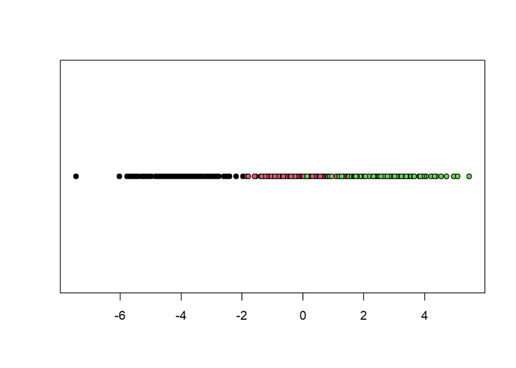

```r
stripchart(data$X,pch=21, bg=data$source)
```

### 10. Plot the histogram corresponding to your generated data. Interpret it.

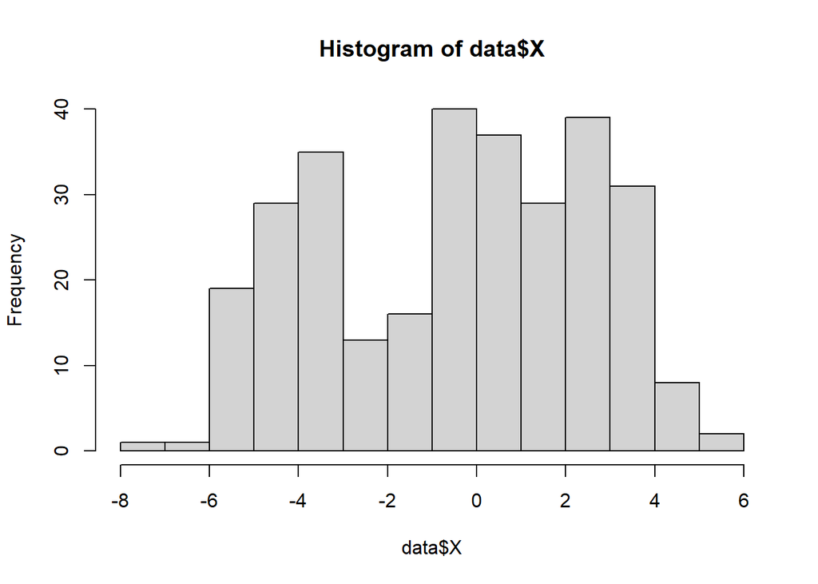

```r
hist(data$X)
```

We can see the 3 gaussian distributions on the histogram.

### 11. Fit a GMM model on your generated data. Print the summary and visualize your results. Explain your results.

```r
gmm.data = Mclust(data$X)
summary(gmm.data)
```

```
## ----------------------------------------------------
## Gaussian finite mixture model fitted by EM algorithm
## ----------------------------------------------------
##
## Mclust E (univariate, equal variance) model with 3 components:
##
##  log-likelihood   n df       BIC       ICL
##       -704.9831 300  6 -1444.189 -1484.432
##
## Clustering table:
##   1   2   3
##  98 103  99
```

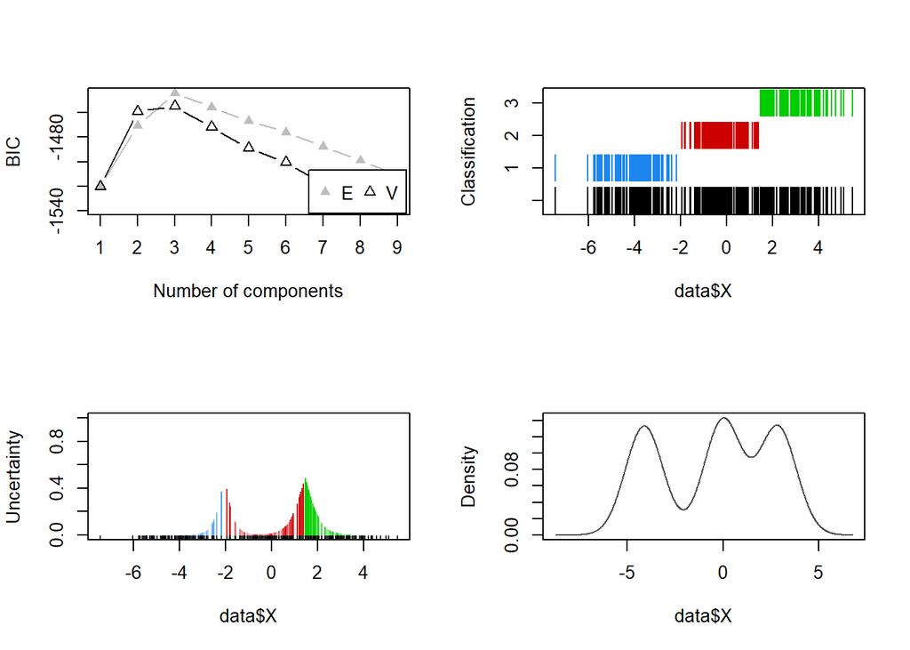

```r
par(mfrow=c(2,2))
plot(gmm.data, what = "BIC")
plot(gmm.data, what = "classification")
plot(gmm.data, what = "uncertainty")
plot(gmm.data, what = "density")
```

I displayed 4 graphs: - BIC: that gives the BIC value for a number of components between 1 and 9, the max value corresponds to the best number of components for our data - Classification: display the class for each data, it is a plot showing the clustering - Uncertainty: a plot of classification uncertainty - Density: display the density function associated to the data

### 12. Apply a density estimate on your generated data and visualize it. Interpret the obtained figure.

```r
data.density.gmm = densityMclust(data$X)
```

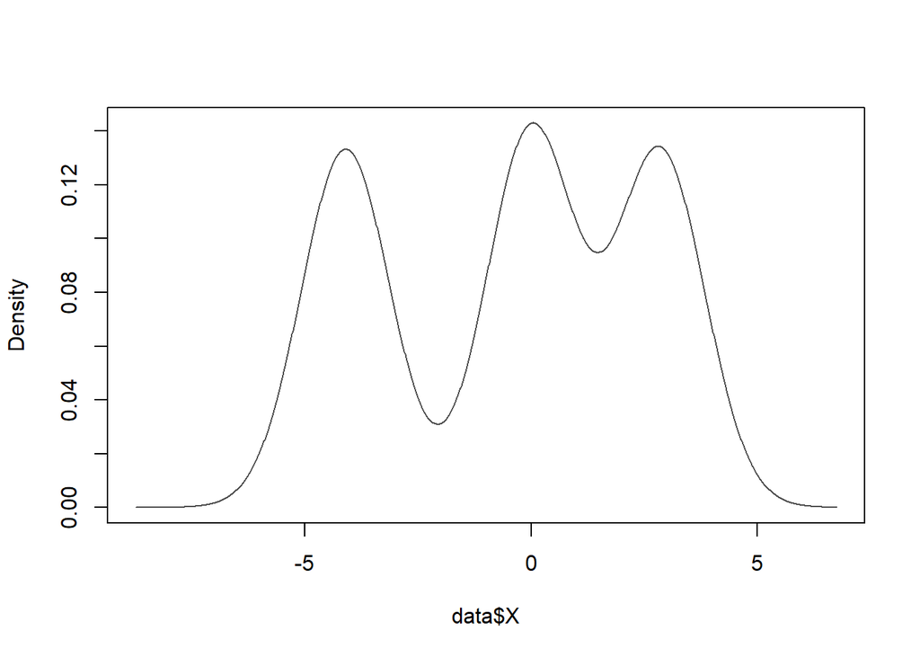

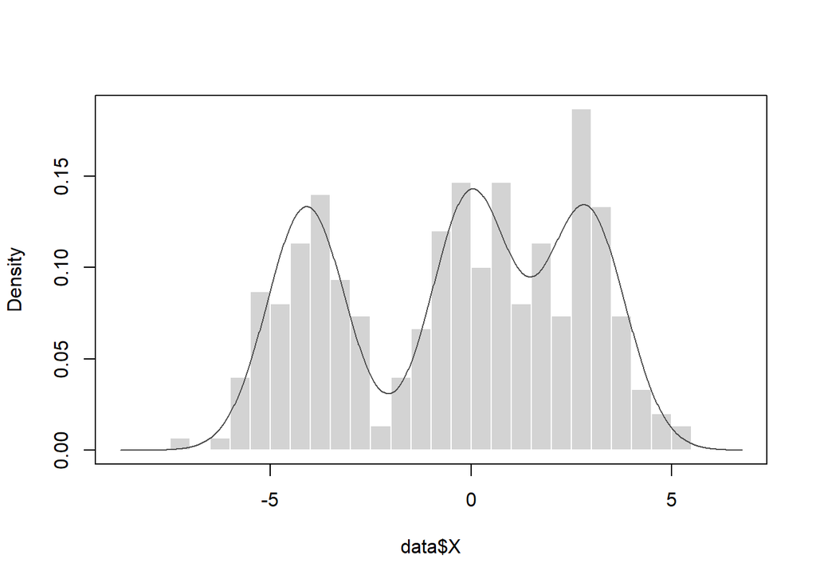

```r
plot(data.density.gmm, what="density",data=data$X,breaks=20)
```

From the distribution, the algorithm identify the distribution function of the 3 gaussians distributions.

# 8.2 EM from scratch

In this second part of this PW you will build a GMM model from scratch, you must develop the EM technique to fit the model.

### 2.1 Generate a two-dimensional dataset from a k-component Gaussian mixture density with different means and different covariance matrices. It is up to you to choose the mixing proportions {π1,…,πk}.

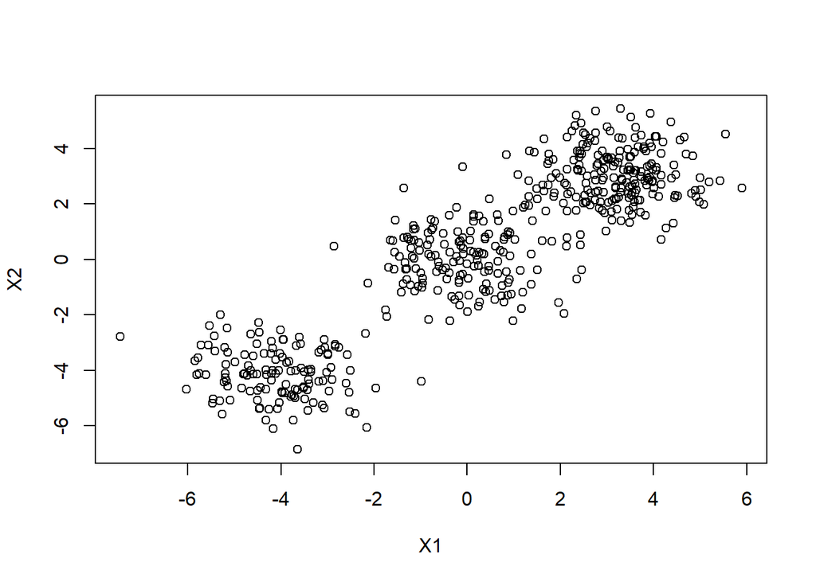

```r
set.seed(183838)
n = 500
n_r = c(130,150,220)
r1 = matrix(rnorm(n_r[1]*2,-4,1), n_r[1], 2)
r2 = matrix(rnorm(n_r[2]*2,0,1), n_r[2], 2)
r3 = matrix(rnorm(n_r[3]*2,3,1), n_r[3], 2)
data = data.frame(X1 = c(r1[,1],r2[,1],r3[,1]),
                  X2 = c(r1[,2],r2[,2],r3[,2]))
pi = c(130/500, 150/300, 220/300)
plot(data)
```

```r
data
```

```
##               X1          X2
## 1   -3.570769424 -3.90718296
## 2   -4.182965228 -3.20295792
## 3   -4.704073460 -3.82645700
## 4   -5.430087712 -2.75974554
## 5   -3.015575666 -4.07644310
## 6   -3.358378229 -4.05590156
## 7   -5.556037725 -3.08104438
## 8   -5.295372760 -1.98360088
## 9   -3.073082791 -2.88818993
## 10  -3.754742279 -4.86902294
## 11  -3.439795027 -4.69908343
## 12  -4.665244289 -4.74865800
## 13  -5.760524486 -4.10661256
## 14  -4.648732764 -2.69114117
```

[output cut: 486 more lines]

```r
k=3

means = runif(k,-10,10)
cov = cov(data)
pi = rep(1/k,k)
```

### 2.3 Create a function that selects the number of mixture components by computing the values of BIC criterion for k varying from 1 to 10.

```r
select_k = function(X){

}
```

[output not shown]

### 2.5 Apply the algorithm you developed on Iris dataset.

```r
iris = read.table('https://www.mghassany.com/MLcourse/datasets/iris.data', header=T, sep=",")
iris
```

```
##     sepal_length sepal_width petal_length petal_width      class
## 1            5.1         3.5          1.4         0.2     setosa
## 2            4.9         3.0          1.4         0.2     setosa
## 3            4.7         3.2          1.3         0.2     setosa
## 4            4.6         3.1          1.5         0.2     setosa
## 5            5.0         3.6          1.4         0.2     setosa
## 6            5.4         3.9          1.7         0.4     setosa
## 7            4.6         3.4          1.4         0.3     setosa
## 8            5.0         3.4          1.5         0.2     setosa
## 9            4.4         2.9          1.4         0.2     setosa
## 10           4.9         3.1          1.5         0.1     setosa
## 11           5.4         3.7          1.5         0.2     setosa
## 12           4.8         3.4          1.6         0.2     setosa
## 13           4.8         3.0          1.4         0.1     setosa
## 14           4.3         3.0          1.1         0.1     setosa
```

[output cut: 136 more lines]